# Lab3_Classification

```r
rm(list=ls())
```

### Predicting The Sales of Carseat

We first use classification trees to analyze the `Carseats` data set. The main goal is to predict the Sales of Carseats and find important features that influence the sales. In these data, Sales is a continuous variable, and so we begin by recoding it as a binary variable. We use the `ifelse()` function to create a variable, called `ifelse()` High, which takes on a value of Yes if the Sales variable exceeds 8, and takes on a value of No otherwise.

```r
library (ISLR)
library(plotly)
```

## Data

A data frame with 400 observations on the following 11 variables.

- `Sales`- Unit sales (in thousands) at each location
- `CompPrice` - Price charged by competitor at each location
- `Income` - Community income level (in thousands of dollars)
- `Advertising` - Local advertising budget for company at each location (in thousands of dollars)
- `Population` - Population size in region (in thousands)
- `Price` - Price company charges for car seats at each site
- `ShelveLoc` - A factor with levels Bad, Good and Medium indicating the quality of the shelving location for the car seats at each site
- `Age` -Average age of the local population
- `Education` -Education level at each location
- `Urban` -A factor with levels No and Yes to indicate whether the store is in an urban or rural location
- `US` -A factor with levels No and Yes to indicate whether the store is in the US or not

```r
head(Carseats)
```

| Sales | CompPrice | Income | Advertising | Population | Price | ShelveLoc | Age | Education | Urban | US |
| --- | --- | --- | --- | --- | --- | --- | --- | --- | --- | --- |
| 9.50 | 138 | 73 | 11 | 276 | 120 | Bad | 42 | 17 | Yes | Yes |
| 11.22 | 111 | 48 | 16 | 260 | 83 | Good | 65 | 10 | Yes | Yes |
| 10.06 | 113 | 35 | 10 | 269 | 80 | Medium | 59 | 12 | Yes | Yes |
| 7.40 | 117 | 100 | 4 | 466 | 97 | Medium | 55 | 14 | Yes | Yes |
| 4.15 | 141 | 64 | 3 | 340 | 128 | Bad | 38 | 13 | Yes | No |
| 10.81 | 124 | 113 | 13 | 501 | 72 | Bad | 78 | 16 | No | Yes |

```r
sum(is.na(Carseats))
```

0

```r
summary(Carseats)
```

```
     Sales          CompPrice       Income        Advertising
 Min.   : 0.000   Min.   : 77   Min.   : 21.00   Min.   : 0.000
 1st Qu.: 5.390   1st Qu.:115   1st Qu.: 42.75   1st Qu.: 0.000
 Median : 7.490   Median :125   Median : 69.00   Median : 5.000
 Mean   : 7.496   Mean   :125   Mean   : 68.66   Mean   : 6.635
 3rd Qu.: 9.320   3rd Qu.:135   3rd Qu.: 91.00   3rd Qu.:12.000
 Max.   :16.270   Max.   :175   Max.   :120.00   Max.   :29.000
   Population        Price        ShelveLoc        Age          Education
 Min.   : 10.0   Min.   : 24.0   Bad   : 96   Min.   :25.00   Min.   :10.0
 1st Qu.:139.0   1st Qu.:100.0   Good  : 85   1st Qu.:39.75   1st Qu.:12.0
 Median :272.0   Median :117.0   Medium:219   Median :54.50   Median :14.0
 Mean   :264.8   Mean   :115.8                Mean   :53.32   Mean   :13.9
 3rd Qu.:398.5   3rd Qu.:131.0                3rd Qu.:66.00   3rd Qu.:16.0
 Max.   :509.0   Max.   :191.0                Max.   :80.00   Max.   :18.0
 Urban       US
 No :118   No :142
 Yes:282   Yes:258
```

```r
Carseats$Income
```

2. 48

3. 35

4. 100

5. 64

6. 113

7. 105

8. 81

9. 110

10. 113

11. 78

12. 94

13. 35

14. 28

15. 117

16. 95

17. 32

18. 74

19. 110

20. 76

21. 90

22. 29

23. 46

24. 31

25. 119

26. 32

27. 115

28. 118

29. 74

30. 99

31. 94

32. 58

33. 32

34. 38

35. 54

36. 84

37. 76

38. 41

39. 73

40. 60

41. 98

42. 53

43. 69

44. 42

45. 79

46. 63

47. 90

48. 98

49. 52

50. 93

51. 32

52. 90

53. 40

54. 64

55. 103

56. 81

57. 82

58. 91

59. 93

60. 71

61. 102

62. 32

63. 45

64. 88

65. 67

66. 26

67. 92

68. 61

69. 69

70. 59

71. 81

72. 51

73. 45

74. 90

75. 68

76. 111

77. 87

78. 71

79. 48

80. 67

81. 100

82. 72

83. 83

84. 36

85. 25

86. 103

87. 84

88. 67

89. 42

90. 66

91. 22

92. 46

93. 113

94. 30

95. 97

96. 25

97. 42

98. 82

99. 77

100. 47

101. 69

102. 93

103. 22

104. 91

105. 96

106. 100

107. 33

108. 107

109. 79

110. 65

111. 62

112. 118

113. 99

114. 29

115. 87

116. 35

117. 75

118. 53

119. 88

120. 94

121. 105

122. 89

123. 100

124. 103

125. 113

126. 78

127. 68

128. 48

129. 100

130. 120

131. 84

132. 69

133. 87

134. 98

135. 31

136. 94

137. 75

138. 42

139. 103

140. 62

141. 60

142. 42

143. 84

144. 88

145. 68

146. 63

147. 83

148. 54

149. 119

150. 120

151. 84

152. 58

153. 78

154. 36

155. 69

156. 72

157. 34

158. 58

159. 90

160. 60

161. 28

162. 21

163. 74

164. 64

165. 64

166. 58

167. 67

168. 73

169. 89

170. 41

171. 39

172. 106

173. 102

174. 91

175. 24

176. 89

177. 107

178. 72

179. 71

180. 25

181. 112

182. 83

183. 60

184. 74

185. 33

186. 100

187. 51

188. 32

189. 37

190. 117

191. 37

192. 42

193. 26

194. 70

195. 98

196. 93

197. 28

198. 61

199. 80

200. 88

201. 92

202. 83

203. 78

204. 82

205. 80

206. 22

207. 67

208. 105

209. 54

210. 21

211. 41

212. 118

213. 69

214. 84

215. 115

216. 83

217. 33

218. 44

219. 61

220. 79

221. 120

222. 44

223. 119

224. 45

225. 82

226. 25

227. 33

228. 64

229. 73

230. 104

231. 60

232. 69

233. 80

234. 76

235. 62

236. 32

237. 34

238. 28

239. 24

240. 105

241. 80

242. 63

243. 46

244. 25

245. 30

246. 43

247. 56

248. 114

249. 52

250. 67

251. 105

252. 111

253. 97

254. 24

255. 104

256. 81

257. 40

258. 62

259. 38

260. 36

261. 117

262. 42

263. 77

264. 26

265. 29

266. 35

267. 93

268. 82

269. 57

270. 69

271. 26

272. 56

273. 33

274. 106

275. 93

276. 119

277. 69

278. 48

279. 113

280. 57

281. 86

282. 69

283. 96

284. 110

285. 46

286. 26

287. 118

288. 44

289. 40

290. 77

291. 111

292. 70

293. 66

294. 84

295. 76

296. 35

297. 44

298. 83

299. 63

300. 40

301. 78

302. 93

303. 77

304. 52

305. 98

306. 29

307. 32

308. 92

309. 80

310. 111

311. 65

312. 68

313. 117

314. 81

315. 33

316. 21

317. 36

318. 30

319. 72

320. 45

321. 70

322. 39

323. 50

324. 105

325. 65

326. 69

327. 30

328. 38

329. 66

330. 54

331. 59

332. 63

333. 33

334. 60

335. 117

336. 70

337. 35

338. 38

339. 24

340. 44

341. 29

342. 120

343. 102

344. 42

345. 80

346. 68

347. 107

348. 39

349. 102

350. 27

351. 101

352. 115

353. 103

354. 67

355. 31

356. 100

357. 109

358. 73

359. 96

360. 62

361. 86

362. 25

363. 55

364. 75

365. 21

366. 30

367. 56

368. 106

369. 22

370. 100

371. 41

372. 81

373. 50

374. 71

375. 47

376. 46

377. 60

378. 61

379. 88

380. 111

381. 64

382. 65

383. 28

384. 117

385. 37

386. 73

387. 116

388. 73

389. 89

390. 42

391. 75

392. 63

393. 42

394. 51

395. 58

396. 108

397. 23

398. 26

399. 79

400. 37

```r
attach(Carseats)
```

```r
Income
```

2. 48

3. 35

4. 100

5. 64

6. 113

7. 105

8. 81

9. 110

10. 113

11. 78

12. 94

13. 35

14. 28

15. 117

16. 95

17. 32

18. 74

19. 110

20. 76

21. 90

22. 29

23. 46

24. 31

25. 119

26. 32

27. 115

28. 118

29. 74

30. 99

31. 94

32. 58

33. 32

34. 38

35. 54

36. 84

37. 76

38. 41

39. 73

40. 60

41. 98

42. 53

43. 69

44. 42

45. 79

46. 63

47. 90

48. 98

49. 52

50. 93

51. 32

52. 90

53. 40

54. 64

55. 103

56. 81

57. 82

58. 91

59. 93

60. 71

61. 102

62. 32

63. 45

64. 88

65. 67

66. 26

67. 92

68. 61

69. 69

70. 59

71. 81

72. 51

73. 45

74. 90

75. 68

76. 111

77. 87

78. 71

79. 48

80. 67

81. 100

82. 72

83. 83

84. 36

85. 25

86. 103

87. 84

88. 67

89. 42

90. 66

91. 22

92. 46

93. 113

94. 30

95. 97

96. 25

97. 42

98. 82

99. 77

100. 47

101. 69

102. 93

103. 22

104. 91

105. 96

106. 100

107. 33

108. 107

109. 79

110. 65

111. 62

112. 118

113. 99

114. 29

115. 87

116. 35

117. 75

118. 53

119. 88

120. 94

121. 105

122. 89

123. 100

124. 103

125. 113

126. 78

127. 68

128. 48

129. 100

130. 120

131. 84

132. 69

133. 87

134. 98

135. 31

136. 94

137. 75

138. 42

139. 103

140. 62

141. 60

142. 42

143. 84

144. 88

145. 68

146. 63

147. 83

148. 54

149. 119

150. 120

151. 84

152. 58

153. 78

154. 36

155. 69

156. 72

157. 34

158. 58

159. 90

160. 60

161. 28

162. 21

163. 74

164. 64

165. 64

166. 58

167. 67

168. 73

169. 89

170. 41

171. 39

172. 106

173. 102

174. 91

175. 24

176. 89

177. 107

178. 72

179. 71

180. 25

181. 112

182. 83

183. 60

184. 74

185. 33

186. 100

187. 51

188. 32

189. 37

190. 117

191. 37

192. 42

193. 26

194. 70

195. 98

196. 93

197. 28

198. 61

199. 80

200. 88

201. 92

202. 83

203. 78

204. 82

205. 80

206. 22

207. 67

208. 105

209. 54

210. 21

211. 41

212. 118

213. 69

214. 84

215. 115

216. 83

217. 33

218. 44

219. 61

220. 79

221. 120

222. 44

223. 119

224. 45

225. 82

226. 25

227. 33

228. 64

229. 73

230. 104

231. 60

232. 69

233. 80

234. 76

235. 62

236. 32

237. 34

238. 28

239. 24

240. 105

241. 80

242. 63

243. 46

244. 25

245. 30

246. 43

247. 56

248. 114

249. 52

250. 67

251. 105

252. 111

253. 97

254. 24

255. 104

256. 81

257. 40

258. 62

259. 38

260. 36

261. 117

262. 42

263. 77

264. 26

265. 29

266. 35

267. 93

268. 82

269. 57

270. 69

271. 26

272. 56

273. 33

274. 106

275. 93

276. 119

277. 69

278. 48

279. 113

280. 57

281. 86

282. 69

283. 96

284. 110

285. 46

286. 26

287. 118

288. 44

289. 40

290. 77

291. 111

292. 70

293. 66

294. 84

295. 76

296. 35

297. 44

298. 83

299. 63

300. 40

301. 78

302. 93

303. 77

304. 52

305. 98

306. 29

307. 32

308. 92

309. 80

310. 111

311. 65

312. 68

313. 117

314. 81

315. 33

316. 21

317. 36

318. 30

319. 72

320. 45

321. 70

322. 39

323. 50

324. 105

325. 65

326. 69

327. 30

328. 38

329. 66

330. 54

331. 59

332. 63

333. 33

334. 60

335. 117

336. 70

337. 35

338. 38

339. 24

340. 44

341. 29

342. 120

343. 102

344. 42

345. 80

346. 68

347. 107

348. 39

349. 102

350. 27

351. 101

352. 115

353. 103

354. 67

355. 31

356. 100

357. 109

358. 73

359. 96

360. 62

361. 86

362. 25

363. 55

364. 75

365. 21

366. 30

367. 56

368. 106

369. 22

370. 100

371. 41

372. 81

373. 50

374. 71

375. 47

376. 46

377. 60

378. 61

379. 88

380. 111

381. 64

382. 65

383. 28

384. 117

385. 37

386. 73

387. 116

388. 73

389. 89

390. 42

391. 75

392. 63

393. 42

394. 51

395. 58

396. 108

397. 23

398. 26

399. 79

400. 37

```r
Carseats$High=ifelse(Sales <=8,0,1)
```

```r
factor(High)
```

2. 1

3. 1

4. 0

5. 0

6. 1

7. 0

8. 1

9. 0

10. 0

11. 1

12. 1

13. 0

14. 1

15. 1

16. 1

17. 0

18. 1

19. 1

20. 1

21. 0

22. 1

23. 0

24. 0

25. 1

26. 1

27. 1

28. 0

29. 0

30. 0

31. 1

32. 1

33. 0

34. 1

35. 0

36. 1

37. 1

38. 0

39. 0

40. 0

41. 0

42. 0

43. 1

44. 0

45. 0

46. 0

47. 1

48. 0

49. 0

50. 1

51. 0

52. 0

53. 0

54. 0

55. 0

56. 0

57. 1

58. 0

59. 0

60. 0

61. 1

62. 0

63. 0

64. 1

65. 0

66. 0

67. 1

68. 1

69. 1

70. 0

71. 1

72. 0

73. 0

74. 1

75. 0

76. 1

77. 1

78. 0

79. 0

80. 1

81. 1

82. 0

83. 1

84. 0

85. 0

86. 1

87. 1

88. 1

89. 0

90. 0

91. 0

92. 0

93. 0

94. 1

95. 1

96. 0

97. 1

98. 0

99. 1

100. 0

101. 0

102. 0

103. 0

104. 0

105. 0

106. 0

107. 0

108. 1

109. 0

110. 1

111. 1

112. 0

113. 0

114. 0

115. 1

116. 1

117. 0

118. 1

119. 0

120. 0

121. 0

122. 1

123. 0

124. 1

125. 1

126. 1

127. 1

128. 0

129. 0

130. 0

131. 1

132. 0

133. 1

134. 0

135. 0

136. 0

137. 0

138. 0

139. 1

140. 1

141. 0

142. 0

143. 0

144. 0

145. 1

146. 1

147. 0

148. 1

149. 0

150. 1

151. 1

152. 1

153. 0

154. 0

155. 0

156. 0

157. 0

158. 1

159. 1

160. 1

161. 0

162. 0

163. 0

164. 0

165. 1

166. 0

167. 0

168. 0

169. 0

170. 1

171. 1

172. 1

173. 1

174. 0

175. 0

176. 0

177. 0

178. 1

179. 1

180. 0

181. 0

182. 0

183. 0

184. 0

185. 1

186. 1

187. 1

188. 0

189. 1

190. 1

191. 1

192. 0

193. 0

194. 1

195. 0

196. 0

197. 0

198. 0

199. 0

200. 0

201. 0

202. 0

203. 0

204. 0

205. 1

206. 0

207. 0

208. 1

209. 0

210. 0

211. 0

212. 1

213. 1

214. 1

215. 0

216. 0

217. 0

218. 0

219. 1

220. 1

221. 1

222. 0

223. 0

224. 0

225. 0

226. 0

227. 0

228. 1

229. 0

230. 1

231. 0

232. 1

233. 1

234. 1

235. 1

236. 0

237. 1

238. 1

239. 0

240. 0

241. 1

242. 1

243. 0

244. 0

245. 1

246. 1

247. 0

248. 0

249. 0

250. 0

251. 1

252. 0

253. 1

254. 0

255. 1

256. 0

257. 0

258. 1

259. 0

260. 0

261. 0

262. 0

263. 0

264. 0

265. 0

266. 0

267. 1

268. 0

269. 0

270. 0

271. 1

272. 0

273. 1

274. 1

275. 0

276. 0

277. 0

278. 0

279. 0

280. 0

281. 0

282. 1

283. 0

284. 0

285. 0

286. 0

287. 0

288. 0

289. 0

290. 1

291. 1

292. 0

293. 1

294. 1

295. 1

296. 0

297. 1

298. 0

299. 1

300. 1

301. 1

302. 0

303. 0

304. 1

305. 1

306. 1

307. 0

308. 0

309. 1

310. 1

311. 1

312. 0

313. 0

314. 1

315. 0

316. 0

317. 1

318. 0

319. 1

320. 0

321. 0

322. 0

323. 1

324. 1

325. 0

326. 1

327. 0

328. 0

329. 0

330. 1

331. 0

332. 1

333. 0

334. 0

335. 0

336. 0

337. 0

338. 1

339. 0

340. 1

341. 0

342. 0

343. 0

344. 0

345. 1

346. 0

347. 1

348. 0

349. 1

350. 1

351. 1

352. 1

353. 1

354. 1

355. 0

356. 0

357. 0

358. 1

359. 0

360. 0

361. 1

362. 1

363. 0

364. 1

365. 1

366. 0

367. 0

368. 1

369. 1

370. 1

371. 0

372. 1

373. 0

374. 0

375. 1

376. 0

377. 1

378. 0

379. 0

380. 0

381. 1

382. 0

383. 0

384. 1

385. 1

386. 0

387. 0

388. 1

389. 1

390. 1

391. 0

392. 0

393. 0

394. 0

395. 0

396. 1

397. 0

398. 0

399. 0

400. 1

```r
head(Carseats)
```

| Sales | CompPrice | Income | Advertising | Population | Price | ShelveLoc | Age | Education | Urban | US | High |
| --- | --- | --- | --- | --- | --- | --- | --- | --- | --- | --- | --- |
| 9.50 | 138 | 73 | 11 | 276 | 120 | Bad | 42 | 17 | Yes | Yes | 1 |
| 11.22 | 111 | 48 | 16 | 260 | 83 | Good | 65 | 10 | Yes | Yes | 1 |
| 10.06 | 113 | 35 | 10 | 269 | 80 | Medium | 59 | 12 | Yes | Yes | 1 |
| 7.40 | 117 | 100 | 4 | 466 | 97 | Medium | 55 | 14 | Yes | Yes | 0 |
| 4.15 | 141 | 64 | 3 | 340 | 128 | Bad | 38 | 13 | Yes | No | 0 |
| 10.81 | 124 | 113 | 13 | 501 | 72 | Bad | 78 | 16 | No | Yes | 1 |

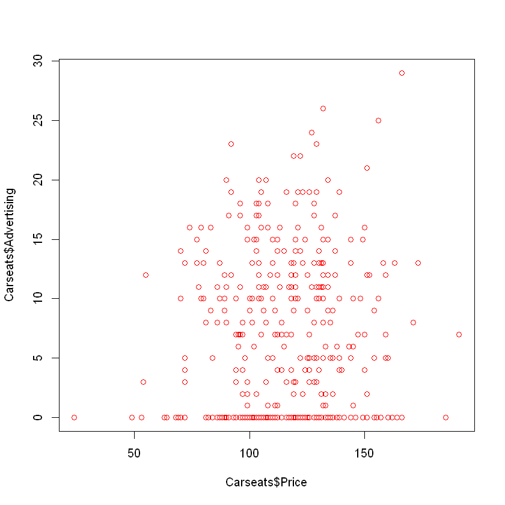

```r
plot(Carseats$Price,Carseats$Advertising,col=c("red","blue")[Carseats$High])
```

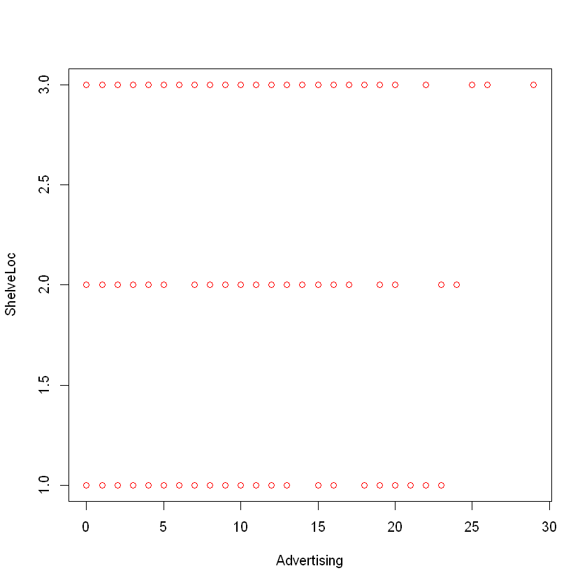

```r
plot(Advertising,ShelveLoc,col=c("red","blue")[High])
```

```r
plot_ly(Carseats, x = ~Price, y = ~Advertising, z = ~ShelveLoc, color = ~High, colors = c('#BF382A', '#0C4B8E')) %>%
  add_markers() %>%
  layout(scene = list(xaxis = list(title = ''),
                     yaxis = list(title = ''),
                     zaxis = list(title = '')))
```

[output not shown]

[output cut: 9 more lines]

[output not shown]

```
HTML widgets cannot be represented in plain text (need html)
```

### Logistic regression

```r
l <- glm(High~. -Sales, data = Carseats, family=binomial)
```

```r
summary(l)
```

```
Call:
glm(formula = High ~ . - Sales, family = binomial, data = Carseats)

Deviance Residuals:
     Min        1Q    Median        3Q       Max
-2.40315  -0.28543  -0.04319   0.18482   2.98849

Coefficients:
                  Estimate Std. Error z value Pr(>|z|)
(Intercept)     -5.0889857  2.4067745  -2.114   0.0345 *
CompPrice        0.1724750  0.0233456   7.388 1.49e-13 ***
Income           0.0341248  0.0079002   4.319 1.56e-05 ***
Advertising      0.2957492  0.0512506   5.771 7.90e-09 ***
Population      -0.0009173  0.0014190  -0.646   0.5180
Price           -0.1674933  0.0196266  -8.534  < 2e-16 ***
ShelveLocGood    8.2408876  1.0328293   7.979 1.48e-15 ***
ShelveLocMedium  3.5970462  0.6520385   5.517 3.46e-08 ***
Age             -0.0793793  0.0142195  -5.582 2.37e-08 ***
Education       -0.0576359  0.0763170  -0.755   0.4501
UrbanYes        -0.3827861  0.4392739  -0.871   0.3835
USYes           -0.6986095  0.5949922  -1.174   0.2403
---
Signif. codes:  0 '***' 0.001 '**' 0.01 '*' 0.05 '.' 0.1 ' ' 1

(Dispersion parameter for binomial family taken to be 1)

    Null deviance: 541.49  on 399  degrees of freedom
Residual deviance: 181.48  on 388  degrees of freedom
AIC: 205.48

Number of Fisher Scoring iterations: 7
```

```r
exp(0.295)
```

1.34312635868628

```r
1-exp(-0.383)
```

0.318187100714009

This fitted model says that, we will see $34\%$ increase in the odds of High Sales for a one-unit increase in `Advertising`,since $exp(0.295) = 1.34$, holding the rest fix. holding the rest at a fixed value, the odds of having High Sales for Stores in Urban areas (Urban = 1) over the odds of having High Sales for non Urban stores is $exp(-0.383) = 0.681$. In terms of percent change, we can say that the odds for Urban stores having high sales are 32% lower than the odds for non Urban.

#### Prediction

```r
set.seed(33)
#data<-read.csv("default1.csv")
test.index <- sample(1:nrow(Carseats), size = 150, replace = F)
test <- Carseats[test.index,]
train <- Carseats[-test.index,]
```

```r
l <- glm(High~. -Sales, data = train, family=binomial)
```

#### In Sample Prediction

```r
l.pred <- predict(l, train, type = "response")
l.pred1 <- as.numeric(l.pred > 0.5)
```

```r
l.table<-table(l.pred1 ,train$High )
l.table
```

```
l.pred1   0   1
      0 139  15
      1  14  82
```

```r
sum(l.pred1)
```

96

```r
(139+82)/250
```

0.884

```r
summary.pred<-function(x)
    {
        FPR<-x[1,2]/sum(x[1,])
        TPR<-x[2,2]/sum(x[2,])
        PPR<-x[2,2]/sum(x[,2])
        NPR<-x[1,1]/sum(x[,1])

        output<-list("FPR"=round(FPR,2),"TPR"=round(TPR,2),"PPR"=round(PPR,2),"NPR"=round(NPR,2))
    return(output)
    }
```

```r
l.pred.summary<-summary.pred(l.table)
l.pred.summary
```

**$FPR**

0.1

**$TPR**

0.85

**$PPR**

0.85

**$NPR**

0.91

#### Out of Sample Prediction

```r
l.pred <- predict(l, test, type = "response")
l.pred1 <- as.numeric(l.pred > 0.5)
```

```r
l.table.test<-table(l.pred1 ,test$High )
l.table.test
```

```
l.pred1  0  1
      0 80 11
      1  3 56
```

```r
(80+56)/150
```

0.906666666666667

```r
l.test.pred.summary<-summary.pred(l.table)
l.test.pred.summary
```

**$FPR**

0.1

**$TPR**

0.85

**$PPR**

0.85

**$NPR**

0.91